# Ch02 整理データを使ったセンチメント分析

人が文章を読むとき, 人は言葉が持つ感情的な 意図について, ポジティブなものかネガティブなものなのか, 驚きとか嫌悪感といったもっと微妙な意味愛を持つ言葉で 表現すべきものかといったことを推論します.

センチメント分析の方法の１つは, テキストを個別の単語の組み合わせと考えて, テキスト全体の感情内容は個別の単語の感情内容の総和と 考えるものである.

# ライブラリー

```r
# load libs
libs <- c( "tidyverse", "tidytext",
           "janeaustenr", "gutenbergr", "scales",
           "wordcloud")
for( lib in libs ) {
    if(!require(lib, character.only = TRUE)) {
        install.packages(lib)
        library(lib, character.only = TRUE)
    }
}
```

# データセット

テキストに含まれる意見や感情を評価するための方法や辞書には さまざまなものがある. `sentiments`データセットには複数の センチメント辞書が含まれている.

```r
sentiments %>% head()
```

| word | sentiment | lexicon | score |
| --- | --- | --- | --- |
| abacus | trust | nrc | NA |
| abandon | fear | nrc | NA |
| abandon | negative | nrc | NA |
| abandon | sadness | nrc | NA |
| abandoned | anger | nrc | NA |
| abandoned | fear | nrc | NA |

ここで使われてる辞書はいずれもユニグラム, つまり単語をぶ分類の単位としている. それぞれの辞書を確認する. どのように単語を評価しているのかは, 辞書ごとに異なることがわかる. ・・・とは言ったものの, 結局のところ数値に変換してしまうのではないだろうか?

```r
dict_name <- c("afinn", "bing", "nrc")
map( dict_name,  ~ head(get_sentiments(.x)) ) %>%
  walk( ~ print(.x))
```

```
## # A tibble: 6 x 2
##   word       score
##   <chr>      <int>
## 1 abandon       -2
## 2 abandoned     -2
## 3 abandons      -2
## 4 abducted      -2
## 5 abduction     -2
## 6 abductions    -2
## # A tibble: 6 x 2
##   word       sentiment
##   <chr>      <chr>
## 1 2-faced    negative
## 2 2-faces    negative
## 3 a+         positive
## 4 abnormal   negative
## 5 abolish    negative
## 6 abominable negative
## # A tibble: 6 x 2
##   word      sentiment
##   <chr>     <chr>
## 1 abacus    trust
## 2 abandon   fear
## 3 abandon   negative
## 4 abandon   sadness
## 5 abandoned anger
## 6 abandoned fear
```

# 内部結合を使ったセンチメント分析

```r
tidy_books <-
  austen_books() %>%
  group_by(book) %>%
  mutate(
    linenumber = row_number(),
    chapter = cumsum(
      str_detect(
        text,
        regex("^chapter [0-9]{1,2}", ignore_case =TRUE)
      )
    )
  ) %>%
  ungroup() %>%
  unnest_tokens(word, text)
tidy_books %>% tail()
```

| book | linenumber | chapter | word |
| --- | --- | --- | --- |
| Persuasion | 8323 | 24 | than |
| Persuasion | 8323 | 24 | in |
| Persuasion | 8323 | 24 | its |
| Persuasion | 8324 | 24 | national |
| Persuasion | 8324 | 24 | importance |
| Persuasion | 8328 | 24 | finis |

```r
# 辞書を使って喜びの単語を取り出す
nrcjoy <-
  get_sentiments("nrc") %>%
  filter(sentiment == "joy")

tidy_books %>%
  filter(book == "Emma") %>%
  inner_join(nrcjoy, by = "word") %>%
  count(word, sort = TRUE)
```

| word | n |
| --- | --- |
| good | 359 |
| young | 192 |
| friend | 166 |
| hope | 143 |
| happy | 125 |
| love | 117 |
| deal | 92 |
| found | 92 |
| present | 89 |
| kind | 82 |

[output cut: 293 more lines]

ネガティブな単語とポジティブな単語を 別の列に分けて, センチメント量(Positive - negative)を求める.

```r
janeaustensentiment <-
  tidy_books %>%
  inner_join(get_sentiments("bing")) %>%
  # 80で割ったときの商でデータを分類
  count(book, index = linenumber %/% 80, sentiment) %>%
  spread(sentiment, n, fill = 0) %>%
  mutate(sentiment = positive - negative)
janeaustensentiment %>% head()
```

| book | index | negative | positive | sentiment |
| --- | --- | --- | --- | --- |
| Sense & Sensibility | 0 | 16 | 32 | 16 |
| Sense & Sensibility | 1 | 19 | 53 | 34 |
| Sense & Sensibility | 2 | 12 | 31 | 19 |
| Sense & Sensibility | 3 | 15 | 31 | 16 |
| Sense & Sensibility | 4 | 16 | 34 | 18 |
| Sense & Sensibility | 5 | 16 | 51 | 35 |

このデータを使うことで, 各作品の流れに沿って センチメントスコアがどのように変化しているかを プロットすることができる.

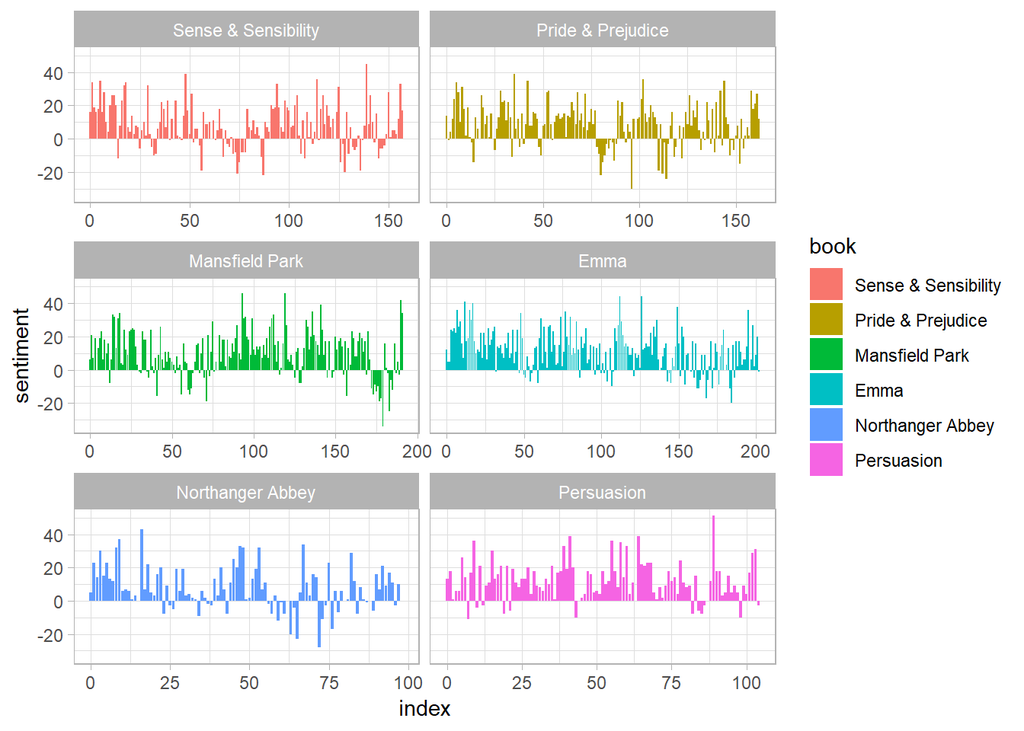

```r
janeaustensentiment %>%
  ggplot(aes(index, sentiment, fill = book)) +
  geom_col(show.legend = TRUE) +
  facet_wrap( ~ book, ncol = 2, scales = "free_x") +
  theme_light()
```

# 3つのセンチメント辞書の比較

辞書を全部使って『高慢と偏見』の筋に沿って 感情がどのように変化しているかを調べる

```r
pride_prejudice <-
  tidy_books %>%
  filter(book == "Pride & Prejudice")

pride_prejudice %>% head()
```

| book | linenumber | chapter | word |
| --- | --- | --- | --- |
| Pride & Prejudice | 1 | 0 | pride |
| Pride & Prejudice | 1 | 0 | and |
| Pride & Prejudice | 1 | 0 | prejudice |
| Pride & Prejudice | 3 | 0 | by |
| Pride & Prejudice | 3 | 0 | jane |
| Pride & Prejudice | 3 | 0 | austen |

```r
# afinnはスコアなので別途計算
afinn <-
  pride_prejudice %>%
  inner_join(get_sentiments("afinn")) %>%
  group_by(index = linenumber %/% 80) %>%
  summarise(sentiment = sum(score)) %>%
  mutate(method = "AFINN")
# bing, nrcは２値分類されているのでそれを使う
bing_and_nrc <- bind_rows(
  pride_prejudice %>%
    inner_join(get_sentiments("bing")) %>%
    mutate(method = "Bing et al."),
  pride_prejudice %>%
    inner_join(get_sentiments("nrc") %>%
               filter(sentiment %in% c("positive", "negative"))) %>%
    mutate(method = "NRC")
) %>%
  count(method, index = linenumber %/% 80, sentiment) %>%
  spread(sentiment, n, fill = 0) %>%
  mutate(sentiment = positive - negative)
```

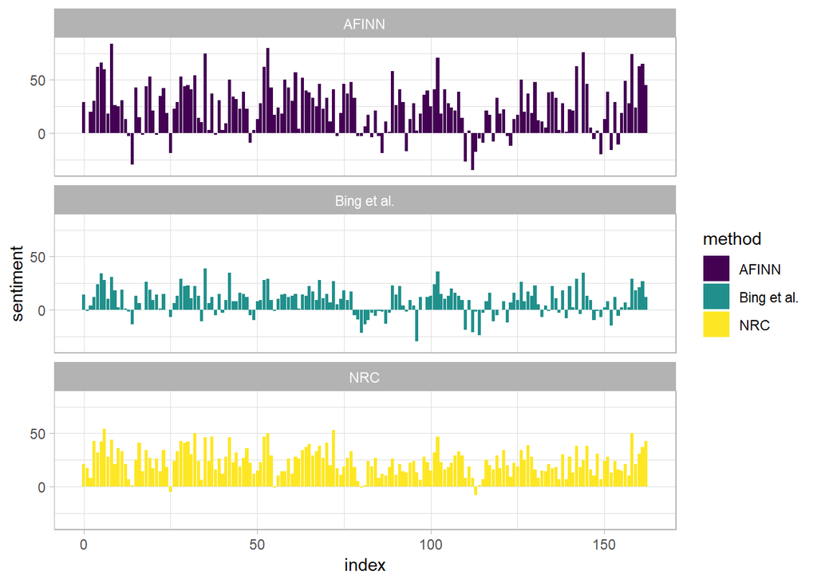

```r
# 3つをまとめる
bind_rows ( afinn, bing_and_nrc ) %>%
  ggplot(aes(index, sentiment, fill = method)) +
  geom_col(show.legend = TRUE) +
  facet_wrap( ~ method, ncol = 1) +
  theme_light() +
  scale_fill_viridis_d()
```

小説の同じような場面で, 感情の起伏があるのがわかるが, その程度は大きく異なるのが見て取れる. AFINNはポジティブ, ネガティブの振れ幅が大きい. Bing辞書は緩徐の絶対値が小さく, ポジティブな単語やネガティブな 感情はつづく. NRCではポジティブな感情に傾いていることがわかる.

ポジティブな感情とネガティブな感情のトークン数を数える

```r
get_sentiments("nrc") %>%
  filter(sentiment %in% c("positive", "negative")) %>%
  count(sentiment)
```

| sentiment | n |
| --- | --- |
| negative | 3324 |
| positive | 2312 |

```r
get_sentiments("bing") %>%
  count(sentiment)
```

| sentiment | n |
| --- | --- |
| negative | 4782 |
| positive | 2006 |

結局, どのような辞書を使うかによって, **センチメント量は異なる**ということを認識しておく必要がある.

# ポジティブ、ネガティブ

```r
bing_word_counts <-
  tidy_books %>%
  inner_join(get_sentiments("bing")) %>%
  count(word, sentiment, sort = TRUE) %>%
  ungroup()
bing_word_counts %>% head()
```

| word | sentiment | n |
| --- | --- | --- |
| miss | negative | 1855 |
| well | positive | 1523 |
| good | positive | 1380 |
| great | positive | 981 |
| like | positive | 725 |
| better | positive | 639 |

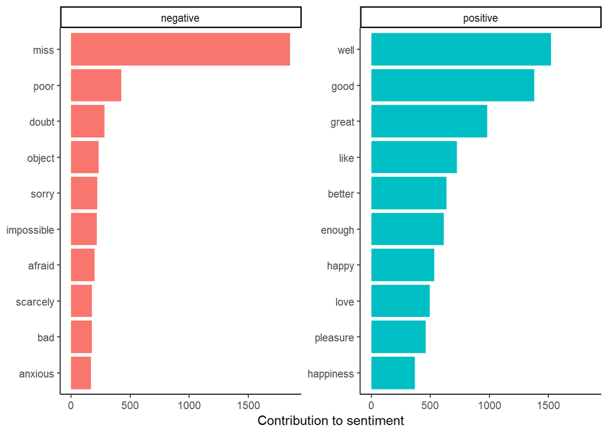

```r
bing_word_counts %>%
  group_by(sentiment) %>%
  top_n(10) %>%
  ungroup() %>%
  mutate(word = reorder(word, n)) %>%
  ggplot(aes(word, n, fill = sentiment)) +
  geom_col(show.legend = F) +
  facet_wrap ( ~ sentiment, scales = "free_y") +
  labs(y = "Contribution to sentiment", x  = NULL) +
  coord_flip() +
  theme_classic()
```

# ワードクラウド

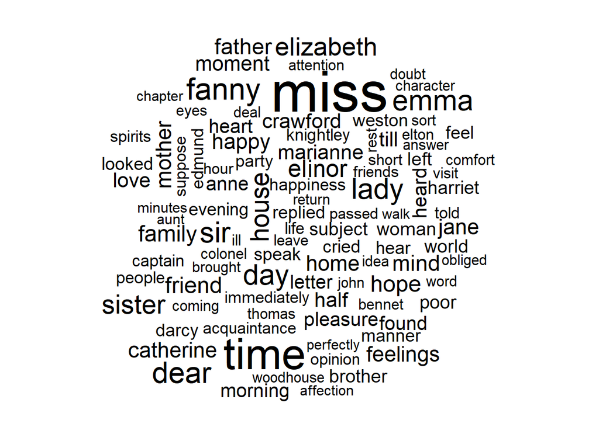

```r
tidy_books %>%
  anti_join(stop_words) %>%
  count(word) %>%
  with(
    wordcloud(word, n, max.words = 100)
  )
```

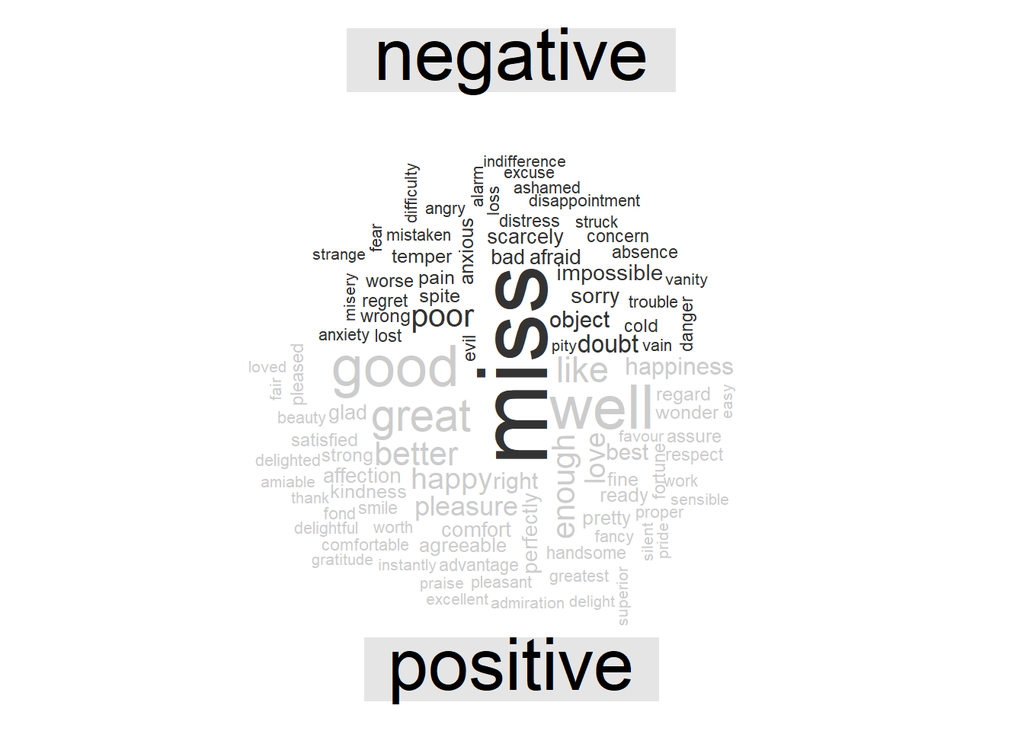

```r
tidy_books %>%
  inner_join(get_sentiments("bing")) %>%
  count(word, sentiment, sort = TRUE) %>%
  reshape2::acast(word ~ sentiment, value.var = "n", fill = 0) %>%
  comparison.cloud(
    colors = c("gray20", "gray80"),
    max.words = 100
  )
```

# 単語を超えた単位

センテンスをトークンにして, 分析することも重要である.

```r
PandP_sentences <-
    data_frame(
      text = prideprejudice
    ) %>%
    unnest_tokens(sentence, text, token = "sentences")
```

実はUTF8よりもASCIIの方が良い変換をするなど, エンコーディングが情報を持つ場合もある. unnest_tokens()は正規表現を使ったトークン化も可能である. 例えば小説を章単位に区切ってデータフレームを 作成することができる..

```r
austen_chapters <-
  austen_books() %>%
  group_by(book) %>%
  unnest_tokens(
    chapter,
    text,
    token = "regex",
    pattern = "Chapter|CHAPTER [\\dIVXLC]"
  ) %>%
  ungroup()

austen_chapters %>%
  group_by(book) %>%
  summarise(chapters = n())
```

| book | chapters |
| --- | --- |
| Sense & Sensibility | 51 |
| Pride & Prejudice | 62 |
| Mansfield Park | 49 |
| Emma | 56 |
| Northanger Abbey | 32 |
| Persuasion | 25 |

このデータフレームを使うことで 「ジェーン・オースティン」の各小説で最も ネガティブな章はどれか」というような問いに 答えることができる.

```r
bingnegative <-
  get_sentiments("bing") %>%
  filter(sentiment =="negative")

wordcounts <-
  tidy_books %>%
  group_by(book, chapter) %>%
  summarise(words = n())

tidy_books %>%
  semi_join(bingnegative) %>%
  group_by(book, chapter) %>%
  summarise(negativewords = n()) %>%
  left_join(wordcounts, by = c("book", "chapter")) %>%
  mutate(ratio = negativewords / words) %>%
  filter(chapter != 0) %>%
  top_n(1) %>%
  ungroup()
```

[output not shown]